# REBCA Housing Anlaysis

## Task 5:

### Model Creation and Testing

Let’s say our goal is to help owners try to figure out what their rental property should be listed for (monthly_rent).

To being with, we clearly have a supervised problem. We have a feature we wish to predict and we have few predictor variables with a modest dataset size. Also, if this were a deployable model we may wish to consider training and testing time. I believe all these features will provide information useful for the model. We are also trying to predict a continuous variable. So we have the following:

1. Supervised Problem
2. Modest data set size
3. Trying to predict a continuous outcome

Given the above, it is reasonable to assume we have to consider a **traditional regression approach** (GLM's, Decision Tree Regressor, SVM's e.t.c). **However**, it may seem appropriate to also consider a basic **Nueral Network** for this task. This may be a potential solution and a multi layer perceptron is always useful for mapping complex functions however, we will have to evaluate the inteprability which is always difficult.

For the sake of this project I will evaluate several traditional supervised regression techniques as well as a basic multi layer perceptron algorithm and evaluate on accuracy.

Before we being, We need to check how our features are correlated with one another:

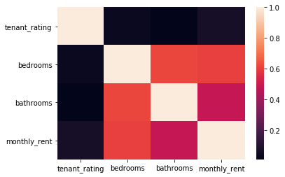

```python
# Visualising the relationships using a pearsons correlation co-efficient method
sns.heatmap(clean_data.corr());
```

So we can clearly see that bathrooms and bedrooms share a reasonable level of correlation. We would call these **latent features**. Essentially, these features are both responsible in predicting another feature of our dataset. My assumption is that this feature is most likely the size of the house. It may be valuable to **remove the bathroom feature to avoid collinearity and model coefficient variation inflation**. We may also see some value in removing the tenant_rating column as it does not seem to provide and relationship to monthly_rent. This may help the model avoid fitting to this column as it provides no indication to the monthly rent price.

I will create our **models with and without the bathrooms** feature to display this inflation phenomenon.

### Supervised Models:

We will be using a Decision Tree Regressor Model, Support Vector Regressor Model and a Gradient Boosting Regressor

##### With bathroom feature:

```python
# Checking the data again
final_clean_data.head()
```

|  | tenant_rating | bedrooms | bathrooms | monthly_rent | listing_type_entire home/apt | listing_type_private room | listing_type_shared room |
| --- | --- | --- | --- | --- | --- | --- | --- |
| 0 | 1.0 | 0.500 | 0.3125 | 2500 | 1 | 0 | 0 |
| 2 | 0.8 | 0.125 | 0.1250 | 820 | 0 | 1 | 0 |
| 3 | 1.0 | 0.000 | 0.1250 | 490 | 1 | 0 | 0 |
| 4 | 0.8 | 0.125 | 0.1250 | 900 | 1 | 0 | 0 |
| 5 | 0.8 | 0.125 | 0.3750 | 650 | 0 | 1 | 0 |

```python
# 1. instantiating our models
Tree_regressor = DecisionTreeRegressor(random_state=0)
SVR_regressor = SVR(kernel='rbf', gamma = 'auto')
Grad_regressor = GradientBoostingRegressor(loss= 'ls',learning_rate=0.1)
```

```python
# 1. Fitting the models
Tree_regressor.fit(X_train, y_train)
SVR_regressor.fit(X_train, y_train)
Grad_regressor.fit(X_train, y_train);
```

```python
# 1. Measuring the training fit (How much variance is explained by the model)
Tree_score = Tree_regressor.score(X_train, y_train)
SVR_score = SVR_regressor.score(X_train, y_train)
Grad_score = Grad_regressor.score(X_train, y_train)
```

```python
# 1. Predicting y values
Tree_y = Tree_regressor.predict(X_val)
SVR_y = SVR_regressor.predict(X_val)
Grad_y = Grad_regressor.predict(X_val)
```

```python
# 1. Measuring the test error
Tree_MAE = mean_absolute_error(y_val, Tree_y)
SVR_MAE = mean_absolute_error(y_val, SVR_y)
Grad_MAE = mean_absolute_error(y_val, Grad_y)
```

```python
# 2. Creating our empty table
indexs = ['R^2', 'MAE($)']
cols = ['Decision Tree Regressor','SVR Regressor', 'Gradient Boosting Regressor']
models_df = pd.DataFrame(index=indexs, columns = cols)
```

```python
# 2. Passing Values to our DataFrame
models_df['Decision Tree Regressor'] = Tree_score, Tree_MAE
models_df['SVR Regressor'] = SVR_score, SVR_MAE
models_df['Gradient Boosting Regressor'] = Grad_score, Grad_MAE
```

```python
# 2. Viewing our DataFrame
models_df
```

|  | Decision Tree Regressor | SVR Regressor | Gradient Boosting Regressor |
| --- | --- | --- | --- |
| R^2 | 0.566646 | 0.007476 | 0.548968 |
| MAE($) | 367.463886 | 479.672139 | 363.613675 |

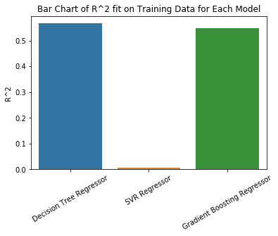

```python
# Creating some visuals to compare the R^2 scores
# Note, a higher R^2 represents a model that is better fitted to the training data
g = sns.barplot(x = list(models_df.columns), y = models_df.iloc[0,0:])
g.set_xticklabels(rotation=30, labels = list(models_df.columns))
plt.title('Bar Chart of R^2 fit on Training Data for Each Model');
```

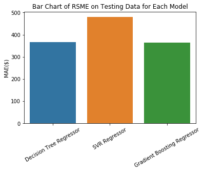

```python
# Creating a visual to understand how well each model predicts the monthly rent
s = sns.barplot(x = list(models_df.columns), y = models_df.iloc[1,0:])
s.set_xticklabels(rotation=30, labels = list(models_df.columns))
plt.title('Bar Chart of RSME on Testing Data for Each Model');
```

So, none of these models perform that well. We need to consider that the models may be inflated with the addition of the bathroom feature. So lets remove it and see what happens.

##### Without bathroom feature:

```python
# Creating a new input features set
X_train_2 = X_train.drop(['bathrooms'], axis=1).copy()
X_val_2 = X_val.drop(['bathrooms'], axis=1).copy()
```

```python
# 1. instantiating our models
Tree_regressor = DecisionTreeRegressor(random_state=0)
SVR_regressor = SVR(kernel='rbf', gamma = 'auto')
Grad_regressor = GradientBoostingRegressor(loss= 'ls',learning_rate=0.1)
```

```python
# 1. Fitting the models
Tree_regressor.fit(X_train_2, y_train)
SVR_regressor.fit(X_train_2, y_train)
Grad_regressor.fit(X_train_2, y_train);
```

```python
# 1. Measuring the training fit (How much variance is explained by the model)
Tree_score = Tree_regressor.score(X_train_2, y_train)
SVR_score = SVR_regressor.score(X_train_2, y_train)
Grad_score = Grad_regressor.score(X_train_2, y_train)
```

```python
# 1. Predicting y values
Tree_y = Tree_regressor.predict(X_val_2)
SVR_y = SVR_regressor.predict(X_val_2)
Grad_y = Grad_regressor.predict(X_val_2)
```

```python
# 1. Measuring the test error
Tree_MAE = mean_absolute_error(y_val, Tree_y)
SVR_MAE = mean_absolute_error(y_val, SVR_y)
Grad_MAE = mean_absolute_error(y_val, Grad_y)
```

```python
# 2. Creating our empty table
indexs = ['R^2', 'MAE($)']
cols = ['Decision Tree Regressor','SVR Regressor', 'Gradient Boosting Regressor']
models_df_2 = pd.DataFrame(index=indexs, columns = cols)
```

```python
# 2. Passing Values to our DataFrame
models_df_2['Decision Tree Regressor'] = Tree_score, Tree_MAE
models_df_2['SVR Regressor'] = SVR_score, SVR_MAE
models_df_2['Gradient Boosting Regressor'] = Grad_score, Grad_MAE
```

```python
# 2. Viewing our DataFrame
models_df_2
```

|  | Decision Tree Regressor | SVR Regressor | Gradient Boosting Regressor |
| --- | --- | --- | --- |
| R^2 | 0.477627 | 0.009358 | 0.476671 |
| MAE($) | 377.211786 | 478.784952 | 377.409564 |

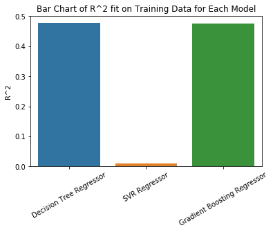

```python
# Creating some visuals to compare the R^2 scores
# Note, a higher R^2 represents a model that is better fitted to the training data
g = sns.barplot(x = list(models_df_2.columns), y = models_df_2.iloc[0,0:])
g.set_xticklabels(rotation=30, labels = list(models_df_2.columns))
plt.title('Bar Chart of R^2 fit on Training Data for Each Model');
```

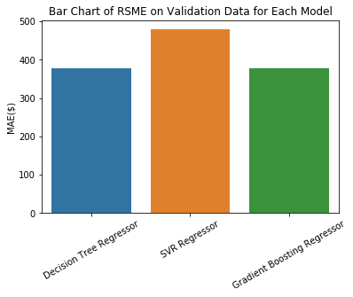

```python
# Creating a visual to understand how well each model predicts the monthly rent
s = sns.barplot(x = list(models_df_2.columns), y = models_df_2.iloc[1,0:])
s.set_xticklabels(rotation=30, labels = list(models_df_2.columns))
plt.title('Bar Chart of RSME on Validation Data for Each Model');
```

This is interesting.

While our models seem to reduce in explaning the variance (smaller R^2 scores), this is most likely due to the fact that the modelling is ignoring more of the *noise* in our dataset.

I believe we can use the full dataset on our Gradient Boosting Regressor with a CV function in order to optimise our model and find the best possible parameters.

#### Optimising the Gradient Boosting Regressor

```python
# Creating our scorer
mae_scorer = make_scorer(mean_absolute_error, greater_is_better=False)
```

```python
parameters = {'n_estimators':[100,150,170,180,190],'learning_rate':[0.2,0.4,0.8,0.9,1],
              'max_depth':[4,5,6]}
```

```python
grid_obj = GridSearchCV(GradientBoostingRegressor(), param_grid=parameters,
                    scoring=mae_scorer, cv = 3)
```

```python
# Fitting the grid search object to the training data and find the optimal parameters using fit()
grid_fit = grid_obj.fit(X_train, y_train)
```

```python
# Geting the estimator
best_mod = grid_fit.best_estimator_
```

```python
# Viewing our model
best_mod
```

```
GradientBoostingRegressor(alpha=0.9, criterion='friedman_mse', init=None,
             learning_rate=0.2, loss='ls', max_depth=4, max_features=None,
             max_leaf_nodes=None, min_impurity_decrease=0.0,
             min_impurity_split=None, min_samples_leaf=1,
             min_samples_split=2, min_weight_fraction_leaf=0.0,
             n_estimators=100, n_iter_no_change=None, presort='auto',
             random_state=None, subsample=1.0, tol=0.0001,
             validation_fraction=0.1, verbose=0, warm_start=False)
```

```python
# Predicting outcomes
best_predictions = best_mod.predict(X_test)
```

```python
# Measuring performance
mae = mean_absolute_error(y_test, best_predictions)
```

```python
print("Our best model is on average, off by \033[1m${:.2f}\033[0m".format(mae))
```

```
Our best model is on average, off by $355.55
```

```python
print("The average monthly rent is \033[1m${:.2f}\033[0m with a standard deviation of \033[1m${:.2f}\033[0m".format(clean_data.monthly_rent.mean(),
                                                                                                                   clean_data.monthly_rent.std()))
```

```
The average monthly rent is $1073.35 with a standard deviation of $828.97
```

## Neural Network

```python
# Setting up the architecture
NN_model = Sequential()

# The Input Layer :
NN_model.add(Dense(128, kernel_initializer='normal',input_dim = X_train.shape[1], activation='relu'))

# The Hidden Layers :
NN_model.add(Dense(256, kernel_initializer='normal',activation='relu'))
NN_model.add(Dense(256, kernel_initializer='normal',activation='relu'))
NN_model.add(Dense(256, kernel_initializer='normal',activation='relu'))

# The Output Layer :
NN_model.add(Dense(1, kernel_initializer='normal',activation='linear'))

# Compile the network :
NN_model.compile(loss='mean_absolute_error', optimizer='adam', metrics=['mean_absolute_error'])
NN_model.summary()
```

```
WARNING:tensorflow:From /anaconda3/lib/python3.7/site-packages/tensorflow/python/framework/op_def_library.py:263: colocate_with (from tensorflow.python.framework.ops) is deprecated and will be removed in a future version.
Instructions for updating:
Colocations handled automatically by placer.
_________________________________________________________________
Layer (type)                 Output Shape              Param #
=================================================================
dense_1 (Dense)              (None, 128)               896
_________________________________________________________________
dense_2 (Dense)              (None, 256)               33024
_________________________________________________________________
dense_3 (Dense)              (None, 256)               65792
_________________________________________________________________
dense_4 (Dense)              (None, 256)               65792
_________________________________________________________________
dense_5 (Dense)              (None, 1)                 257
=================================================================
Total params: 165,761
Trainable params: 165,761
Non-trainable params: 0
_________________________________________________________________
```

```python
# Storing our model
# Running 1000 epochs just for insurance
model_hist = NN_model.fit(X_train, y_train, epochs=1000, batch_size=32, validation_split = 0.2)
```

```
WARNING:tensorflow:From /anaconda3/lib/python3.7/site-packages/tensorflow/python/ops/math_ops.py:3066: to_int32 (from tensorflow.python.ops.math_ops) is deprecated and will be removed in a future version.
Instructions for updating:
Use tf.cast instead.
Train on 3416 samples, validate on 855 samples
```

```python
# Double checking our keys
print(model_hist.history.keys())
```

```
dict_keys(['val_loss', 'val_mean_absolute_error', 'loss', 'mean_absolute_error'])
```

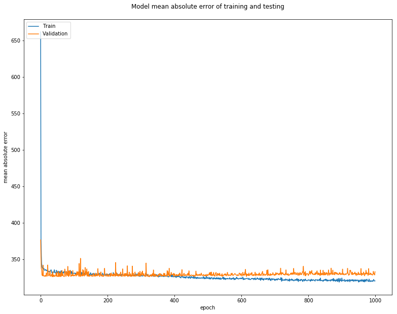

```python
# Plotting the performance of our model vs the number of epocs
fig, ax= plt.subplots()
fig.set_size_inches(13, 10)
plt.plot(model_hist.history['mean_absolute_error'])
plt.plot(model_hist.history['val_mean_absolute_error'])
plt.title('Model mean absolute error of training and testing\n')
plt.ylabel('mean absolute error')
plt.xlabel('epoch')
plt.legend(['Train', 'Validation'], loc='upper left')
plt.show()
```

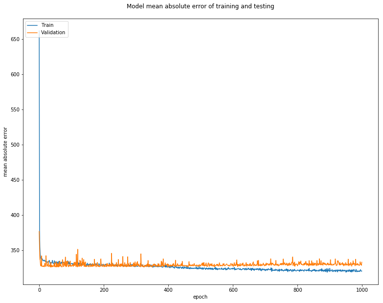

```python
# Plotting the performance of our model vs the number of epocs
fig, ax= plt.subplots()
fig.set_size_inches(13, 10)
plt.plot(model_hist.history['loss'])
plt.plot(model_hist.history['val_loss'])
plt.title('Model mean absolute error of training and testing\n')
plt.ylabel('mean absolute error')
plt.xlabel('epoch')
plt.legend(['Train', 'Validation'], loc='upper left')
plt.show()
```

Interesting to note, we seem to have reached an optimum validation around 400 epochs. There tends to be some noise with the validation score but that may just be due to the validation sets variation.

### Task 6 - Let’s test the model

- Use the appropriate datasets you made in Task 4 to see how well your model performs. Plot the predicted monthly_rent and actual monthly_rent as a line graph. Make sure to add labels so we know what we are looking at.
- If it’s not performing as well as you had hoped, explain what you could try changing to improve.
- Repeat part a with the validation set

```python
# Generating a list of predictions from the test set
predicted_test = NN_model.predict(X_test)
```

```python
# Number of test values
len(predicted_test)
```

```
1220
```

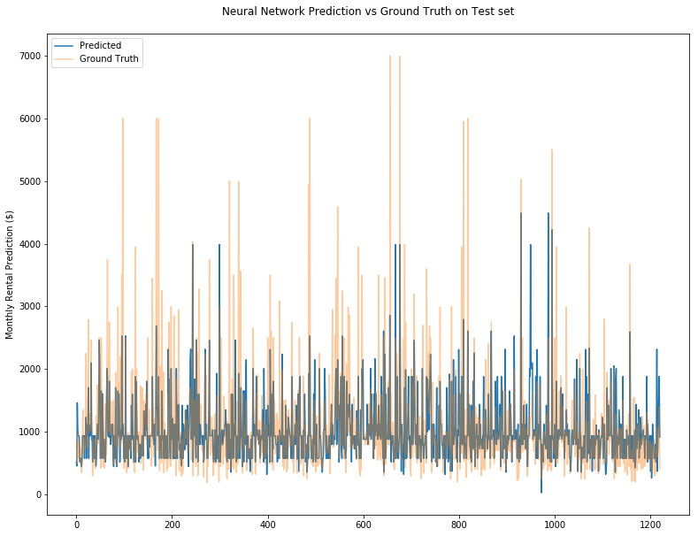

```python
# Plotting the predictions of our model vs the ground truth for the test set
fig, ax= plt.subplots()
fig.set_size_inches(13, 10)
plt.plot(predicted_test)
plt.plot(y_test, alpha = 0.4)
plt.title('Neural Network Prediction vs Ground Truth on Test set\n')
plt.ylabel('Monthly Rental Prediction ($)')
plt.legend(['Predicted', 'Ground Truth'], loc='upper left')
plt.show()
```

The model seems to be able to predict prices that are near average rental price fairly well. However, there seems to be a lot of difficulty in predicting the variation. It seems that it was unable to learn how to predict the edge cases (remember we didnt have a great distribution across almost all of our features).

```python
# Generating a list of predictions from the validation set
predicted_val = NN_model.predict(X_val)
```

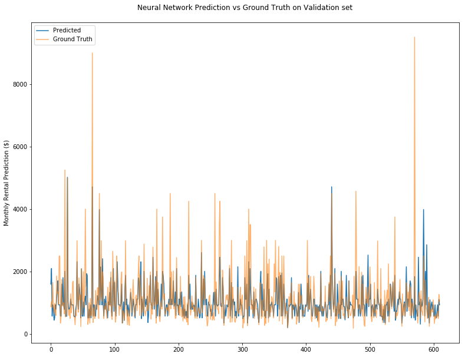

```python
# Plotting the predictions of our model vs the ground truth for the test set
fig, ax= plt.subplots()
fig.set_size_inches(13, 10)
plt.plot(predicted_val)
plt.plot(y_val, alpha = 0.6)
plt.title('Neural Network Prediction vs Ground Truth on Validation set\n')
plt.ylabel('Monthly Rental Prediction ($)')
plt.legend(['Predicted', 'Ground Truth'], loc='upper left')
plt.show()
```

Here we can see the same, the model tends to match the validation set fairly well within a certain range however it has great difficulty in predicting higher than normal rental prices.

```python
# Measuring performance
mae = mean_absolute_error(y_test, predicted_test)
```

```python
print("Our best model is on average, off by \033[1m${:.2f}\033[0m".format(mae))
```

```
Our best model is on average, off by $347.30
```

# Conclusion

So, we can conclude. Our finest model is the Neural Network we developed. However, we only **increased performance of the prediction by an average of 8 dollars**. Not the greatest. But there are a few changes we could make to improve our model.

1. Remove outliers from our features so that they closely resemble normal distributions.
2. Increase number of layers/nodes in our perceptron algorithm in order to better estimate what seems to be a complex function.
3. Try other optimizers such as SGD/AdaGrad/AdaDelta.
4. Run a grid search function to optimize the parameters.
- Train the model with a dropout rate (avoid certain connections in the network from over compensating).

All of the above is not a difficult task to complete. However, when optimizing a Neural Network, it is computationally expensive and time consuming. Also, we still have great difficulty when it comes to model interpretability. Our supervised models tend to allow us to have a better look at what is really going on.

As always, more data makes for better models. I would recommend only splitting the data into testing and training sets for the Multi-Layer-Perceptron. Thus allowing for the model to be trained and validated on a larger set of data. I recommend this [outline](https://machinelearningmastery.com/much-training-data-required-machine-learning/) that evaluates why you may need more data depending on your model. It discusses how exceedingly non-linear models (Deep Learning models) tend to keep imroving with higher volumes of data.

As always, your favorite data nerd.

- *Surohit Tandon*

p.s. Dad Joke for the day!:

- "Spiders are the only web developers that enjoy finding bugs..."

[figure not shown]